# Week 9 Problem Set

## Cohort Session

```python
import numpy as np
import pandas as pd
import matplotlib.pyplot as plt
import seaborn as sns
```

**CS0.** *Plot:* Read data for Boston Housing Prices and write a function `get_features_targets()` to get the columns for the features and the targets from the input argument data frame. The function should take in Pandas' dataframe and two lists. The first list is for the feature names and the other list is for the target names.

We will use the following columns for our test cases:

- x data: RM column - use z normalization (standardization)
- y data: MEDV column

**Make sure you return a new data frame for both the features and the targets.**

We will normalize the feature using z normalization. Plot the data using scatter plot.

```python
def normalize_z(df):
    ### BEGIN SOLUTION
    dfout = df.copy()
    dfout = (df - df.mean(axis=0)) / df.std(axis=0)
    return dfout
    ### END SOLUTION
    pass
```

```python
def get_features_targets(df, feature_names, target_names):
    ### BEGIN SOLUTION
    df_feature = df[feature_names]
    df_target = df[target_names]
    ### END SOLUTION
    pass
    return df_feature, df_target
```

```python
df = pd.read_csv("housing_processed.csv")
df_feature, df_target = get_features_targets(df,["RM"],["MEDV"])
df_feature = normalize_z(df_feature)

assert isinstance(df_feature, pd.DataFrame)
assert isinstance(df_target, pd.DataFrame)
assert np.isclose(df_feature.mean(), 0.0)
assert np.isclose(df_feature.std(), 1.0)
assert np.isclose(df_target.mean(), 22.532806)
assert np.isclose(df_target.std(), 9.1971)
```

```python
### BEGIN HIDDEN TESTS
df = pd.read_csv("housing_processed.csv")
df_feature1, df_target1 = get_features_targets(df,["MEDV"],["DIS"])
df_feature1 = normalize_z(df_feature1)
#display(df_feature.describe())
#display(df_target.describe())
assert isinstance(df_feature1, pd.DataFrame)
assert isinstance(df_target1, pd.DataFrame)
assert np.isclose(df_feature1.mean(), 0.0)
assert np.isclose(df_feature1.std(), 1.0)
assert np.isclose(df_target1.mean(), 3.795043)
assert np.isclose(df_target1.std(), 2.10571)
### END HIDDEN TESTS
```

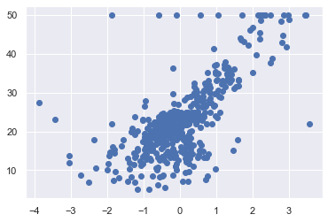

```python
sns.set()
plt.scatter(df_feature, df_target)
```

**CS1.** *Cost Function:* Write a function `compute_cost()` to compute the cost function of a linear regression model. The function should take in two 2-D numpy arrays. The first one is the matrix of the linear equation and the second one is the actual target value.

Recall that:

$$J(\hat{\beta}_0, \hat{\beta}_1) = \frac{1}{2m}\Sigma^m_{i=1}\left(\hat{y}(x^i)-y^i\right)^2$$

where

$$\hat{y}(x^i) = \hat{\beta}_0 + \hat{\beta}_1 x^i$$

The function should receive a numpy array, so we will need to convert to numpy array and change the shape. To do this, we will create two other functions:

- `prepare_feature(df)`: which takes in a data frame for the feature. The function should convert the data frame to a numpy array and change it into a column vector. The function should also add a column of constant 1s in the first column.
- `prepare_target(df)`: which takes in a data frame for the target. The function should simply convert the data frame to a numpy array and change it into column vectors. **The function should be able to handle if the data frame has more than one column.**

You can use the following methods in your code:

- `df.to_numpy()`: which is to convert a Pandas data frame to Numpy array.
- `np.reshape(row, col)`: which is to reshape the numpy array to a particular shape.
- `np.concatenate((array1, array2), axis)`: which is to join a sequence of arrays along an existing axis.
- `np.matmul(array1, array2)`: which is to do matrix multiplication on two Numpy arrays.

```python
def compute_cost(X, y, beta):
    J = 0
    ### BEGIN SOLUTION
    m = X.shape[0]
    error = np.matmul(X, beta) - y
    error_sq = np.matmul(error.T, error)
    J = (1/(2 * m)) * error_sq
    J = J[0][0]
    ### END SOLUTION
    return J
```

```python
def prepare_feature(df_feature):
    ### BEGIN SOLUTION
    cols = len(df_feature.columns)
    feature = df_feature.to_numpy().reshape(-1, cols)
    X = np.concatenate((np.ones((feature.shape[0],1)), feature), axis=1)
    return X
    ### END SOLUTION
    pass
```

```python
def prepare_target(df_target):
    ### BEGIN SOLUTION
    cols = len(df_target.columns)
    target = df_target.to_numpy().reshape(-1, cols)
    return target
    ### END SOLUTION
    pass
```

```python
X = prepare_feature(df_feature)
target = prepare_target(df_target)

assert isinstance(X, np.ndarray)
assert isinstance(target, np.ndarray)
assert X.shape == (506, 2)
assert target.shape == (506, 1)
```

```python
### BEGIN HIDDEN TESTS
X1 = prepare_feature(df_feature1)
target1 = prepare_target(df_target1)

assert isinstance(X1, np.ndarray)
assert isinstance(target1, np.ndarray)
assert X1.shape == (506, 2)
assert target1.shape == (506, 1)
### END HIDDEN TESTS
```

```python
# print(X)
beta = np.zeros((2,1))
J = compute_cost(X, target, beta)
print(J)
assert np.isclose(J, 296.0735)

beta = np.ones((2,1))
J = compute_cost(X, target, beta)
print(J)
assert np.isclose(J, 268.157)

beta = np.array([-1, 2]).reshape((2,1))
J = compute_cost(X, target, beta)
print(J)
assert np.isclose(J, 308.337)
```

```
296.0734584980237
268.15700514868996
308.33699448710337
```

```python
### BEGIN HIDDEN TESTS
# print(X)
beta1 = np.zeros((2,1))
J1 = compute_cost(X1, target1, beta1)
#print(J1)
assert np.isclose(J1, 9.4138)

beta1 = np.ones((2,1))
J1 = compute_cost(X1, target1, beta1)
#print(J1)
assert np.isclose(J1, 6.0925)

beta1 = np.array([-1, 2]).reshape((2,1))
J1 = compute_cost(X1, target1, beta1)
#print(J1)
assert np.isclose(J1, 14.6544)
### END HIDDEN TESTS
```

**CS2.** *Gradient Descent:* Write a function called `gradient_descent()` that takes in these parameters:

- `X`: is a 2-D numpy array for the features
- `y`: is a vector array for the target
- `beta`: is a column vector for the initial guess of the parameters
- `alpha`: is the learning rate
- `num_iters`: is the number of iteration to perform

The function should return two numpy arrays:

- `beta`: is coefficient at the end of the iteration
- `J_storage`: is the array that stores the cost value at each iteration

You can use some of the following functions:

- `np.matmul(array1, array2)`: which is to do matrix multiplication on two Numpy arrays.
- `compute_cost()`: which the function you created in the previous problem set to compute the cost.

```python
def gradient_descent(X, y, beta, alpha, num_iters):
    ### BEGIN SOLUTION
    m = X.shape[0]
    J_storage = np.zeros((num_iters, 1))
    for n in range(num_iters):
        deriv = np.matmul(X.T, (np.matmul(X, beta) - y))
        beta = beta - alpha * (1 / m) * deriv
        J_storage[n] = compute_cost(X, y, beta)
    ### END SOLUTION
    return beta, J_storage
```

```python
iterations = 1500
alpha = 0.01
beta = np.zeros((2,1))

beta, J_storage = gradient_descent(X, target, beta, alpha, iterations)
print(beta)
assert np.isclose(beta[0], 22.5328)
assert np.isclose(beta[1], 6.3953)
```

```
[[22.53279993]
 [ 6.39529594]]
```

```python
### BEGIN HIDDEN TESTS
iterations1 = 1500
alpha1 = 0.01
beta1 = np.zeros((2,1))

beta1, J_storage1 = gradient_descent(X1, target1, beta1, alpha1, iterations1)
#print(beta1)
assert np.isclose(beta1[0], 3.79504161)
assert np.isclose(beta1[1], 0.5262773)
### END HIDDEN TESTS
```

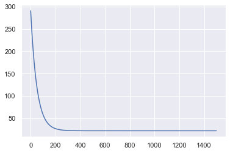

```python
plt.plot(J_storage)
```

**CS3.** *Predict:* Write two functions `predict()` and `predict_norm()` that calculate the straight line equation given the features and its coefficient.

- `predict()`: this function should standardize the feature using z normalization, change it to a Numpy array, and add a column of constant 1s. You should use `prepare_feature()` for this purpose. Lastly, this function should also call `predict_norm()` to get the predicted y values.
- `predict_norm()`: this function should calculate the straight line equation after standardization and adding of column for constant 1.

You can use some of the following functions:

- `np.matmul(array1, array2)`: which is to do matrix multiplication on two Numpy arrays.
- `normalize_z(df)`: which is to do z normalization on the data frame.

```python
def predict_norm(X, beta):
    ### BEGIN SOLUTION
    return np.matmul(X, beta)
    ### END SOLUTION
    pass
```

```python
def predict(df_feature, beta):
    ### BEGIN SOLUTION
    X = prepare_feature(normalize_z(df_feature))
    return predict_norm(X, beta)
    ### END SOLUTION
    pass
```

```python
df_feature, buf = get_features_targets(df, ["RM"], [])
beta = [[22.53279993],[ 6.39529594]] # from previous result
pred = predict(df_feature, beta)

assert isinstance(pred, np.ndarray)
assert pred.shape == (506, 1)
assert np.isclose(pred.mean(), 22.5328)
assert np.isclose(pred.std(), 6.38897)
```

```python
### BEGIN HIDDEN TESTS
df_feature1, buf = get_features_targets(df, ["MEDV"], [])
beta1 = [[3.79504161],[ 0.5262773]] # from previous result
pred1 = predict(df_feature1, beta1)
#display(pred1.std())
assert isinstance(pred1, np.ndarray)
assert pred1.shape == (506, 1)
assert np.isclose(pred1.mean(),  3.795043)
assert np.isclose(pred1.std(), 0.525757)
### END HIDDEN TESTS
```

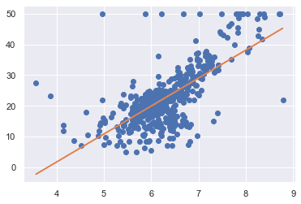

```python
plt.plot(df_feature["RM"],target,'o')
plt.plot(df_feature["RM"],pred,'-')
```

**CS4.** *Splitting data:* Do the following tasks:

- Read RM as the feature and MEDV as the target from the data frame.
- Use Week 9's function `split_data()` to split the data into train and test using `random_state=100` and `test_size=0.3`.
- Normalize and prepare the features and the target.
- Use the training data set and call `gradient_descent()` to obtain the `theta`.
- Use the test data set to get the predicted values.

You need to replace the `None` in the code below with other a function call or any other Python expressions.

```python
def split_data(df_feature, df_target, random_state=None, test_size=0.5):
    ### BEGIN SOLUTION
    indexes = df_feature.index
    if random_state != None:
        np.random.seed(random_state)
    k = int(test_size * len(indexes))
    test_index = np.random.choice(indexes, k, replace=False)
    indexes = set(indexes)
    test_index = set(test_index)
    train_index = indexes - test_index
    df_feature_train = df_feature.loc[train_index, :]
    df_feature_test = df_feature.loc[test_index, :]
    df_target_train = df_target.loc[train_index, :]
    df_target_test = df_target.loc[test_index, :]
    ### END SOLUTION
    return df_feature_train, df_feature_test, df_target_train, df_target_test
```

```python
# get features and targets from data frame
df_feature, df_target = (None, None)

# split the data into training and test data sets
df_feature_train, df_feature_test, df_target_train, df_target_test = (None, None, None, None)

# normalize the feature using z normalization
df_feature_train_z = None

X = None
target = None

iterations = 1500
alpha = 0.01
beta = np.zeros((2,1))

# call the gradient_descent function
beta, J_storage = None, None

# call the predict method to get the predicted values
pred = None

### BEGIN SOLUTION
df_feature, df_target = get_features_targets(df, ["RM"], ["MEDV"])
df_feature_train, df_feature_test, df_target_train, df_target_test = split_data(df_feature, df_target, random_state=100, test_size=0.3)
df_feature_train_z = normalize_z(df_feature_train)
X = prepare_feature(df_feature_train_z)
target = prepare_target(df_target_train)

iterations = 1500
alpha = 0.01
beta = np.zeros((2,1))
beta, J_storage = gradient_descent(X, target, beta, alpha, iterations)
pred = predict(df_feature_test, beta)
### END SOLUTION
```

```python
assert isinstance(pred, np.ndarray)
assert pred.shape == (151, 1)
assert np.isclose(pred.mean(), 22.66816)
assert np.isclose(pred.std(), 6.257265)
```

```python
### BEGIN HIDDEN TESTS
assert isinstance(pred, np.ndarray)
assert pred.shape == (151, 1)
#print(pred.max())
assert np.isclose(pred.min(), 4.6204)
assert np.isclose(pred.max(), 46.27084)
### END HIDDEN TESTS
```

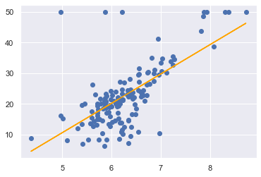

```python
plt.scatter(df_feature_test, df_target_test)
plt.plot(df_feature_test, pred, color="orange")
```

**CS5.** *R2 Coefficient of Determination:* Write a function to calculate the coefficient of determination as given by the following equations.

$$r^2 = 1 - \frac{SS_{res}}{SS_{tot}}$$

where

$$SS_{res} = \Sigma_{i=1}^n (y_i - \hat{y}_i)^2$$

where $y_i$ is the actual target value and $\hat{y}_i$ is the predicted target value.

$$SS_{tot} = \Sigma_{i=1}^n (y_i - \overline{y})^2$$

where $$ \overline{y} = \frac{1}{n} \Sigma_{i=1}^n y_i$$ and $n$ is the number of target values.

You can use the following functions in your code:

- `np.mean(array)`: which is to get the mean of the array. You can also call it using `array.mean()`.
- `np.sum(array)`: which is to sum the array along a default axis. You can specify which axis to perform the summation.

```python
def r2_score(y, ypred):
    ### BEGIN SOLUTION
    ymean = np.mean(y)
    sstot = np.sum((y - ymean)**2)
    ssres = np.sum((y - ypred)**2)
    return 1 - (ssres/sstot)
    ### END SOLUTION
    pass
```

```python
target = prepare_target(df_target_test)
r2 = r2_score(target, pred)
assert np.isclose(r2, 0.45398)
```

**CS6.** *Mean Squared Error:* Create a function to calculate the MSE as given below.

$$MSE = \frac{1}{n}\Sigma_{i=1}^n(y^i - \hat{y}^i)^2$$

```python
def mean_squared_error(target, pred):
    ### BEGIN SOLUTION
    n = target.shape[0]
    return (1/n)*np.sum((target - pred)**2)
    ### END SOLUTION
    pass
```

```python
mse = mean_squared_error(target, pred)
assert np.isclose(mse, 53.6375)
```

**CS8.** *Optional:* Redo the above tasks using Sci-kit learn libraries. You will need to use the following:

- [LinearRegression](https://scikit-learn.org/stable/modules/generated/sklearn.linear_model.LinearRegression.html)
- [train_test_split](https://scikit-learn.org/stable/modules/generated/sklearn.model_selection.train_test_split.html)
- [r2_score](https://scikit-learn.org/stable/modules/generated/sklearn.metrics.r2_score.html)
- [mean_squared_error](https://scikit-learn.org/stable/modules/generated/sklearn.metrics.mean_squared_error.html)

```python
from sklearn.linear_model import LinearRegression
from sklearn.model_selection import train_test_split
from sklearn.metrics import r2_score, mean_squared_error
```

```python
# Read the CSV and extract the features
df = None
df_feature, df_target = None, None
# normalize
df_feature = None

### BEGIN SOLUTION
df = pd.read_csv("housing_processed.csv")
df_feature, df_target = get_features_targets(df, ["RM"], ["MEDV"])
df_feature = normalize_z(df_feature)
### END SOLUTION
```

```python
# Split the data into training and test data set using scikit-learn function
df_feature_train, df_feature_test, df_target_train, df_target_test = None, None, None, None

# Instantiate LinearRegression() object
model = None

# Call the fit() method
pass

### BEGIN SOLUTION
df_feature_train, df_feature_test, df_target_train, df_target_test = train_test_split(df_feature, df_target, random_state=100, test_size=0.3)

model = LinearRegression()
model.fit(df_feature_train, df_target_train)
### END SOLUTION

print(model.coef_, model.intercept_)
assert np.isclose(model.coef_,[6.05090511])
assert np.isclose(model.intercept_, 22.52999668)
```

```
[[6.05090511]] [22.52999668]
```

```python
# Call the predict() method
pred = None

### BEGIN SOLUTION
pred = model.predict(df_feature_test)
### END SOLUTION

print(type(pred), pred.mean(), pred.std())
assert isinstance(pred, np.ndarray)
assert np.isclose(pred.mean(), 22.361699)
assert np.isclose(pred.std(), 5.7011267)
```

```
<class 'numpy.ndarray'> 22.3616994893565 5.7011267141173
```

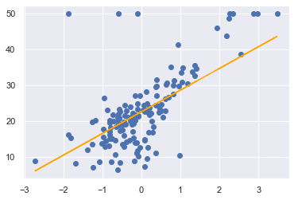

```python
plt.scatter(df_feature_test, df_target_test)
plt.plot(df_feature_test, pred, color="orange")
```

```python
r2 = r2_score(df_target_test, pred)
print(r2)
assert np.isclose(r2, 0.457647)
```

```
0.45764736329252076
```

```python
mse = mean_squared_error(df_target_test, pred)
print(mse)
assert np.isclose(mse, 54.93216)
```

```
54.93216051758423
```